# Machine learning assignment

Oleksii Yehorchenkov

30 11 2020

This assignment is based on materials from Coursera course [Practical machine learning](https://www.coursera.org/learn/practical-machine-learning/home/welcome)

## Background

Using devices such as Jawbone Up, Nike FuelBand, and Fitbit it is now possible to collect a large amount of data about personal activity relatively inexpensively. These type of devices are part of the quantified self movement – a group of enthusiasts who take measurements about themselves regularly to improve their health, to find patterns in their behavior, or because they are tech geeks. One thing that people regularly do is quantify how much of a particular activity they do, but they rarely quantify how well they do it. In this project, your goal will be to use data from accelerometers on the belt, forearm, arm, and dumbell of 6 participants. They were asked to perform barbell lifts correctly and incorrectly in 5 different ways. More information is available from the website here: http://groupware.les.inf.puc-rio.br/har (see the section on the Weight Lifting Exercise Dataset).

## Data

The training data for this project are available here:

https://d396qusza40orc.cloudfront.net/predmachlearn/pml-training.csv

The test data are available here:

https://d396qusza40orc.cloudfront.net/predmachlearn/pml-testing.csv

The data for this project come from this source: http://groupware.les.inf.puc-rio.br/har. If you use the document you create for this class for any purpose please cite them as they have been very generous in allowing their data to be used for this kind of assignment.

## What you should do

The goal of your project is to predict the manner in which they did the exercise. This is the “classe” variable in the training set. You may use any of the other variables to predict with. You should create a report describing how you built your model, how you used cross validation, what you think the expected out of sample error is, and why you made the choices you did. You will also use your prediction model to predict 20 different test cases.

Also you should explain how do you deal with NA’s values and investigate correlation.

You repository for this assignment should consist of R markdown file, compiled html file and prediction.csv file with data from pml-testing.csv and ‘classe’ column with predictions for 20 observation.

```r
library(caret)
library(dplyr)
testingOriginal <- read.csv("../data/pml-testing.csv")
testing <- testingOriginal %>% select(-X)
training <- read.csv("../data/pml-training.csv") %>% select(-X)
```

Check if all columns are named the same:

```r
if (!all(colnames(testing[,1:ncol(testing)-1]) == colnames(training[,1:ncol(training)-1]))) {
    raise
}
```

Filter out zero variance columns (first in training, then in testing to have the correct variables afterwards):

```r
nearZeroVarianceIndices <- nearZeroVar(training)
filteredTraining <- training[, -nearZeroVarianceIndices]
filteredTesting <- testing[, -nearZeroVarianceIndices]
```

```r
numsNoNa <- unlist(sapply(filteredTraining, function(column) {
    all(!is.na(column))
}))
filteredTrainingWithoutNa <- filteredTraining[, numsNoNa]
filteredTestingWithoutNa <- filteredTesting[, numsNoNa]
```

Maybe filter out columns with high correlation to other features, but we don’t need this if we’re using decision trees/random forests because there is a high probability that will filter out the correlated features on their own.

Add prediction value again, if it was lost in the column filtering somewhere

```r
filteredTrainingWithoutNa$expectedClass <- training$classe
filteredTestingWithoutNa$expectedClass <- testing$problem_id
```

Build up the decision tree

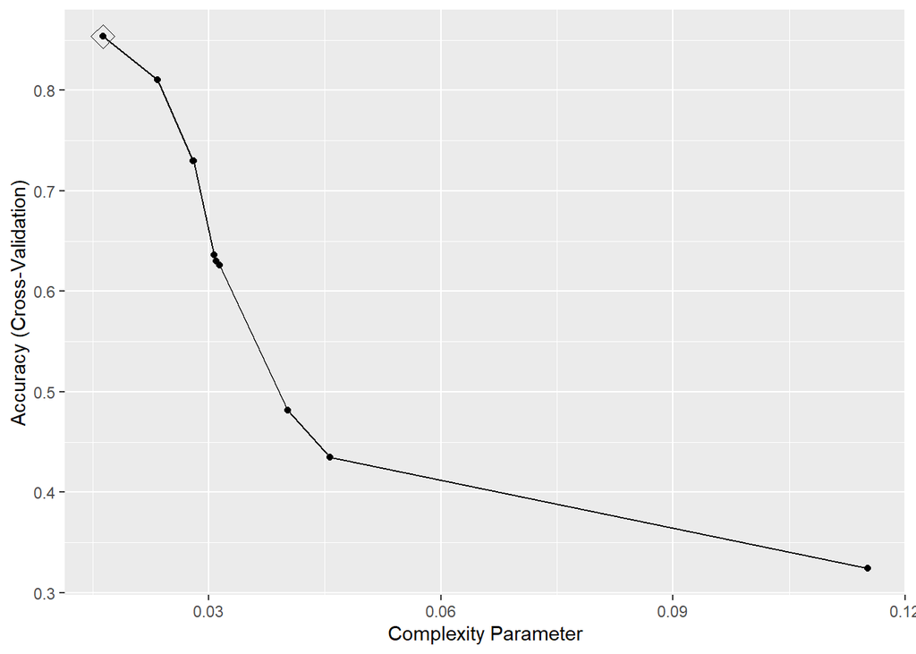

```r
control <- trainControl(method = "cv", number = 10, p = .9)
#train(filteredTrainingWithoutNa, filteredTrainingWithoutNa$expectedClass, method='LMT', iter='1')

train_rpart <- train(expectedClass ~ ., data = filteredTrainingWithoutNa %>% select(-classe),
                     method = "rpart",
                     trControl = control,
                     tuneLength = 10)
ggplot(train_rpart, highlight = TRUE)
```

[figure not shown]

```r
library(rattle)
fancyRpartPlot(train_rpart$finalModel, uniform=TRUE,cex=0.5)
```

Filter out: user_name, raw_timestamp_part_1, raw_timestamp_part_2, cvtd_timestamp, num_window because they are likely to be irrelevant

```r
extendedFilteringTraining <- filteredTrainingWithoutNa %>% select(-user_name, -raw_timestamp_part_1, -raw_timestamp_part_2, -cvtd_timestamp, -num_window)
extendedFilteringTesting <- filteredTestingWithoutNa %>% select(-user_name, -raw_timestamp_part_1, -raw_timestamp_part_2, -cvtd_timestamp, -num_window)
```

Another tree:

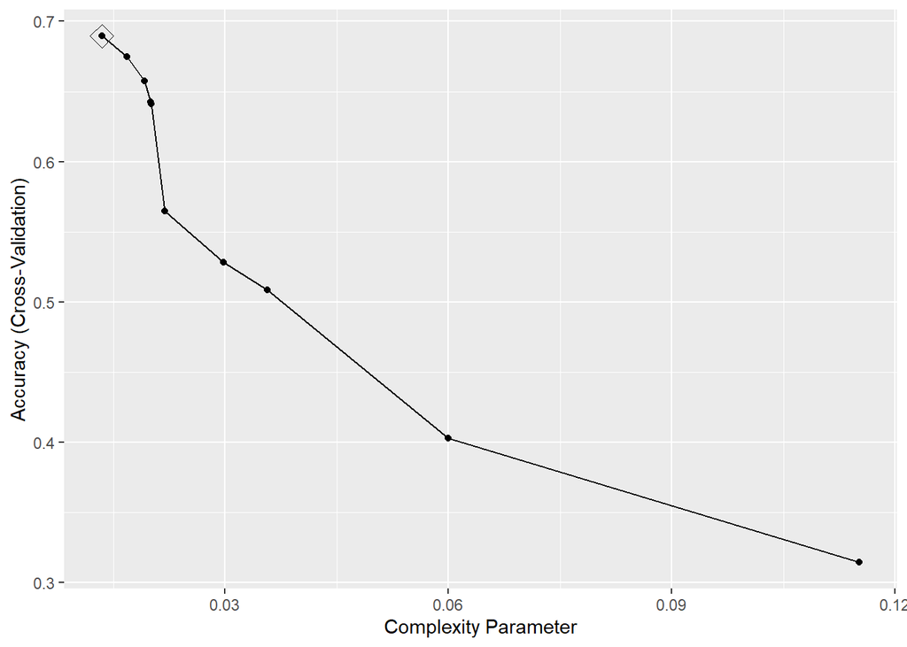

```r
control <- trainControl(method = "cv", number = 10, p = .9)
#train(filteredTrainingWithoutNa, filteredTrainingWithoutNa$expectedClass, method='LMT', iter='1')

train_rpartExtended <- train(expectedClass ~ ., data = extendedFilteringTraining %>% select(-classe),
                     method = "rpart",
                     trControl = control,
                     tuneLength = 10)
ggplot(train_rpartExtended, highlight = TRUE)
```

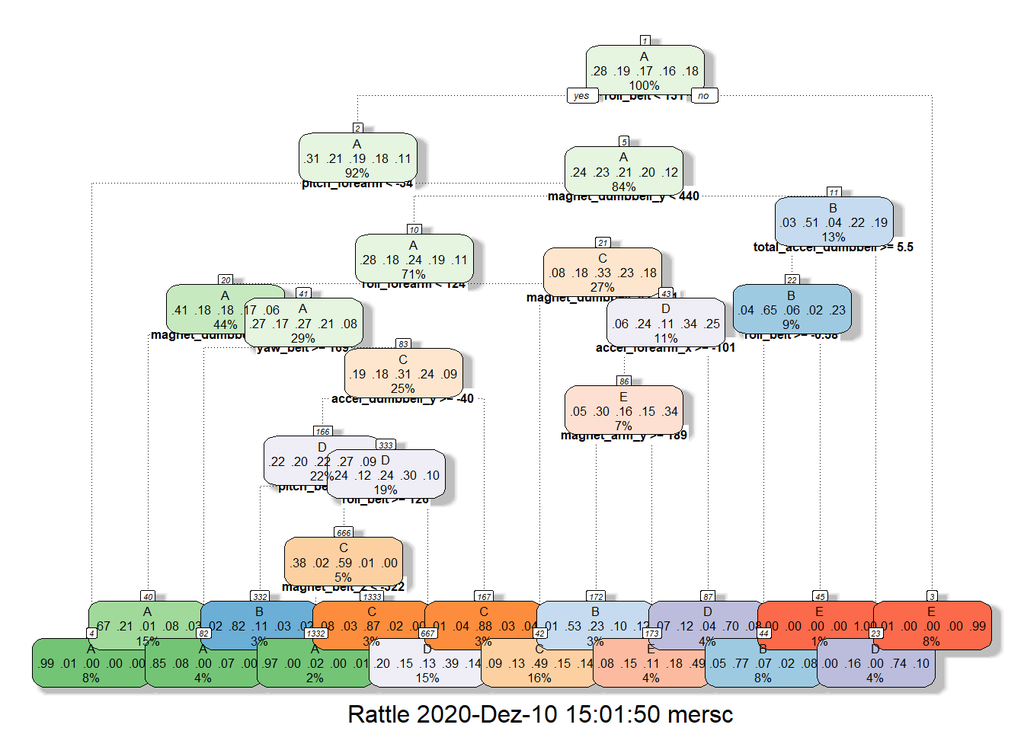

```r
library(rattle)
fancyRpartPlot(train_rpartExtended$finalModel, uniform=TRUE,cex=0.5)
```

Calculate accuracy:

```r
training$prediction <- predict(train_rpartExtended, extendedFilteringTraining)
result <- training %>% select(classe, prediction)
nrow(result %>% filter(classe == prediction))/nrow(training)
```

```
## [1] 0.6857099
```

Prediction:

```r
testingOriginal$prediction <- predict(train_rpartExtended, extendedFilteringTesting)
result <- testingOriginal %>% select(X, prediction)
write.csv(result, "../data/predictedThroughRpart.csv")
```

Prediction with Random forest:

[figure not shown]

```r
library(parallel)
library(doParallel)
cluster <- makeCluster(detectCores() - 1) # convention to leave 1 core for OS
registerDoParallel(cluster)

control <- trainControl(method = "cv", number = 10, p = .9, allowParallel = TRUE)

train_randomForest <- train(expectedClass ~ ., data = extendedFilteringTraining %>% select(-classe),
                     method = "rf",
                     trControl = control,
                     tuneGrid = NULL)
stopCluster(cluster)
registerDoSEQ()
ggplot(train_rpartExtended, highlight = TRUE)
```

Calculate accuracy:

```r
training$prediction <- predict(train_randomForest, extendedFilteringTraining)
result <- training %>% select(classe, prediction)
nrow(result %>% filter(classe == prediction))/nrow(training)
```

```
## [1] 1
```

Prediction:

```r
testingOriginal$prediction <- predict(train_randomForest, extendedFilteringTesting)
result <- testingOriginal %>% select(X, prediction)
write.csv(result, "../data/predictedThroughRandomForest.csv")
```

Prediction with SVM:

```r
library(parallel)
library(doParallel)
cluster <- makeCluster(detectCores() - 1) # convention to leave 1 core for OS
registerDoParallel(cluster)

library(kernlab)
control <- trainControl(method = "cv", number = 10, p = .9, allowParallel = TRUE)
svm_Linear <- train(expectedClass ~., data = extendedFilteringTraining %>% select(-classe), method = "svmLinear",
                 trControl=control,
                 preProcess = c("center", "scale"),
                 tuneLength = 4)

stopCluster(cluster)
registerDoSEQ()
```

Calculate accuracy:

```r
training$prediction <- predict(svm_Linear, extendedFilteringTraining)
result <- training %>% select(classe, prediction)
nrow(result %>% filter(classe == prediction))/nrow(training)
```

```
## [1] 0.7927836
```

Prediction:

```r
testingOriginal$prediction <- predict(svm_Linear, extendedFilteringTesting)
result <- testingOriginal %>% select(X, prediction)
write.csv(result, "../data/predictedThroughSvmLinear.csv")
```

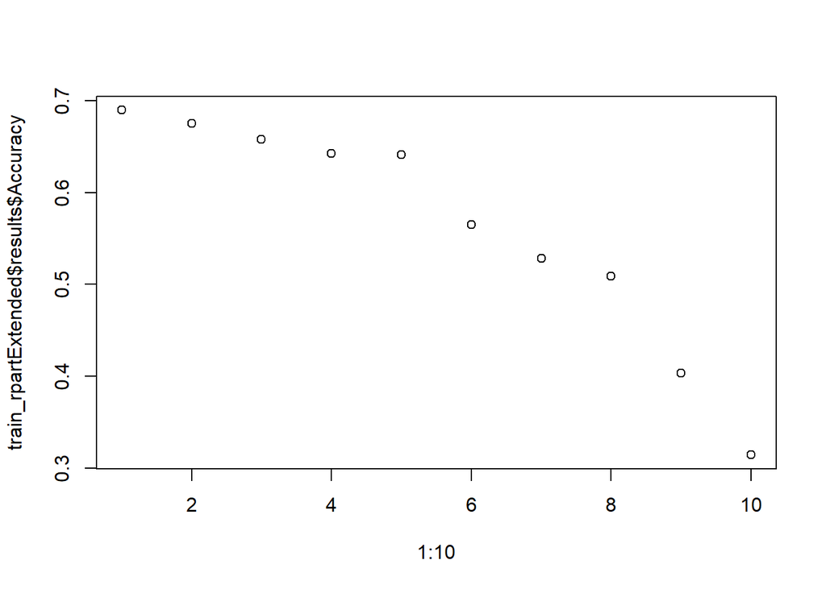

```r
plot(1:10, train_rpartExtended$results$Accuracy)
```

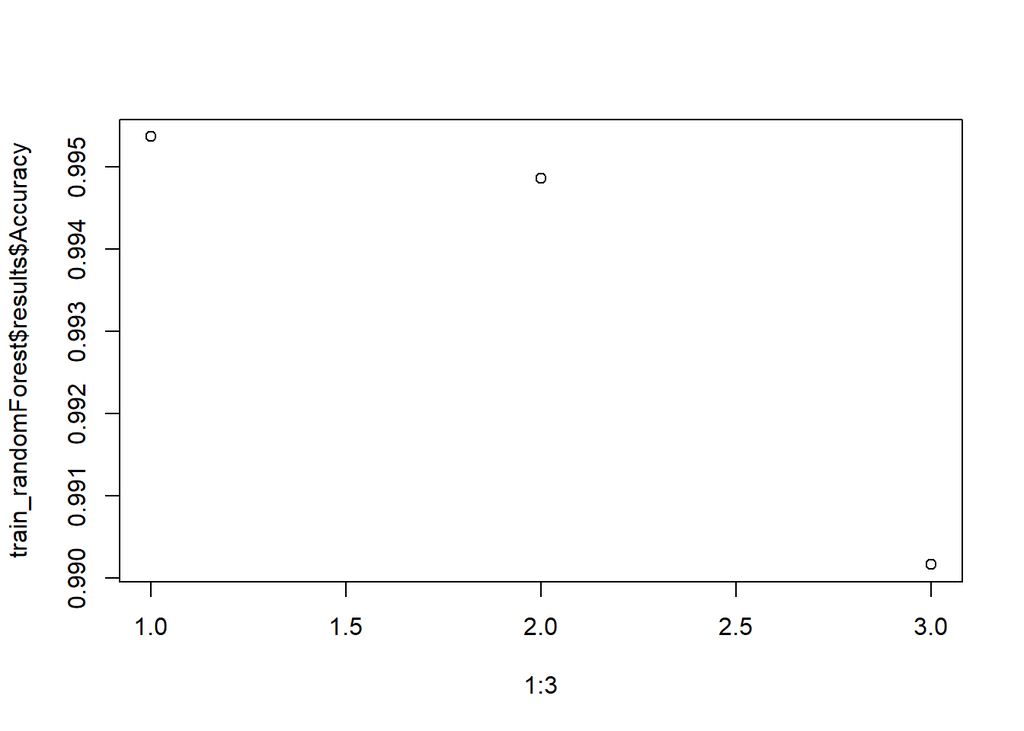

```r
plot(1:3, train_randomForest$results$Accuracy)
```

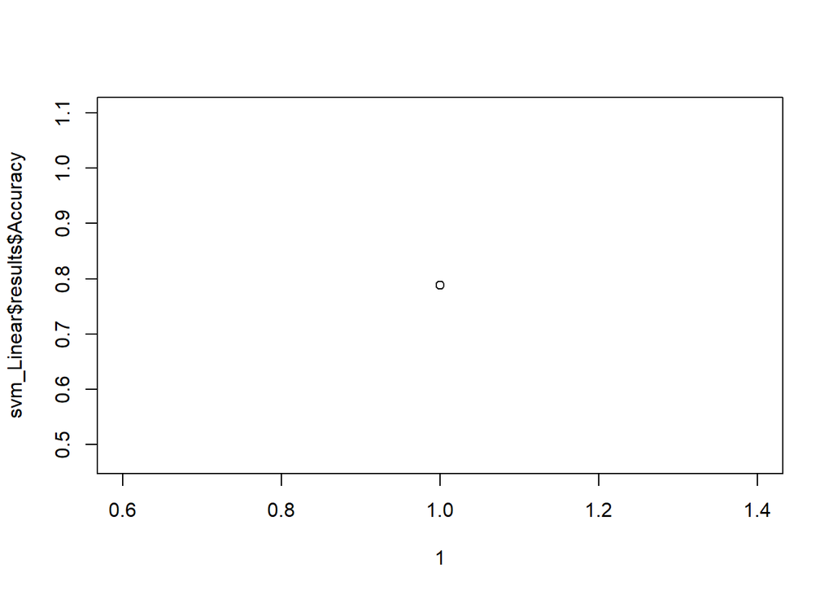

```r
plot(1, svm_Linear$results$Accuracy)
```